# R Notebook

Load and explore the data held in heart.csv. A data dictionary is also available.

```r
library(janitor)
library(tidyverse)
heart <- read_csv('data/heart.csv')
```

Plot a histogram and/or boxplot for thalach (maximum heart rate achieved in stress testing). How normal is the distribution?

[figure not shown]

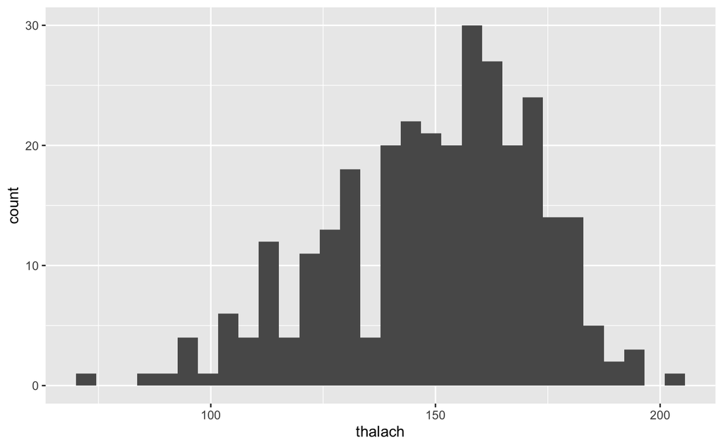

```r
heart %>% ggplot(aes(thalach))+
  geom_histogram()
```

Also plot a barplot of exang (whether the patient displayed exercise induced angina)

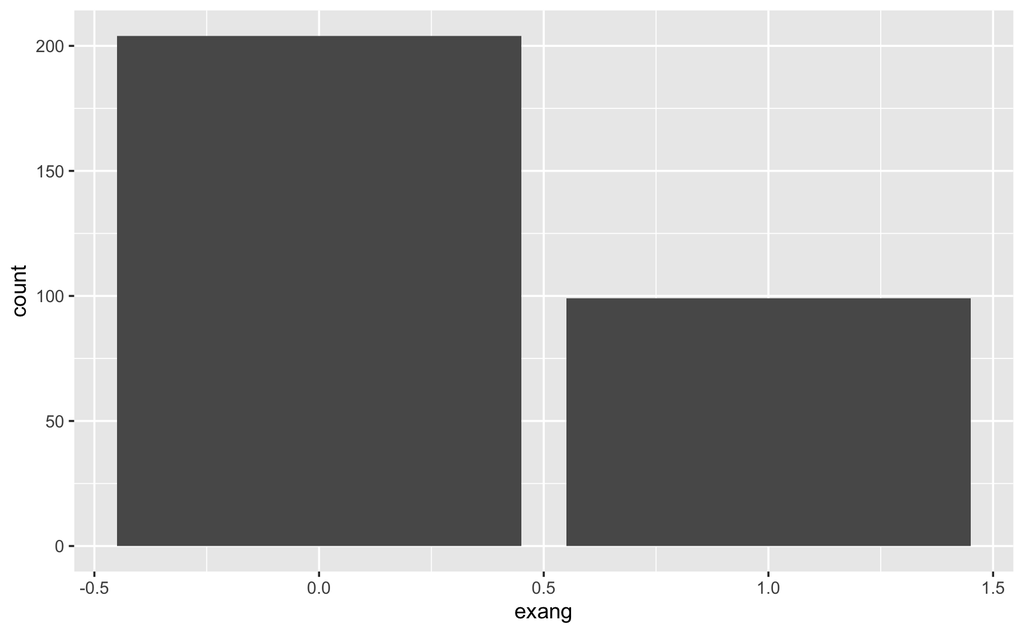

```r
heart %>%
  ggplot(aes(x = exang))+
  geom_bar()
```

Now calculate population parameters: what is the mean thalach in the population. What proportion of patients have exercise induced angina (exang)?

| mean_thalach | prop_exang |
| --- | --- |
| 149.6469 | 0.3267327 |

Now take a single sample of 50-patients from the population and calculate point estimates for mean thalach and proportion of exang from this sample (let’s call these mean_thalach and prop_exang going forward). [Hint - use rep_sample_n() from the infer package to do this]

| mean_thalach | prop_exang |
| --- | --- |
| 152.6 | 0.24 |

What are the sampling errors of these point estimates? [Hint - remember a sampling error is defined as the difference between a point estimate drawn from a sample, and a population parameter]

```r
sum_heart %>%
  summarise(
    se_mean_thalach = sum_heart$mean_thalach - sum_50$mean_thalach,
    se_prop_exang = sum_heart$prop_exang - sum_50$prop_exang
  )
```

| se_mean_thalach | se_prop_exang |
| --- | --- |
| -2.953135 | 0.08673267 |

Now we’re going to repeatedly sample 50-patients from the population and build up sampling distributions for the mean_thalach and prop_exang point estimates. Take 5000 samples and store the sampling distributions in a variable rep_sample_50. [Hint - again, use rep_sample_n() to do this.]

| replicate | age | sex | cp | trestbps | chol | fbs | restecg | thalach | exang | oldpeak | slope | ca | thal | target |
| --- | --- | --- | --- | --- | --- | --- | --- | --- | --- | --- | --- | --- | --- | --- |
| 1 | 69 | 1 | 2 | 140 | 254 | 0 | 0 | 146 | 0 | 2.0 | 1 | 3 | 3 | 0 |
| 1 | 55 | 0 | 1 | 135 | 250 | 0 | 0 | 161 | 0 | 1.4 | 1 | 0 | 2 | 1 |
| 1 | 71 | 0 | 1 | 160 | 302 | 0 | 1 | 162 | 0 | 0.4 | 2 | 2 | 2 | 1 |
| 1 | 42 | 1 | 3 | 148 | 244 | 0 | 0 | 178 | 0 | 0.8 | 2 | 2 | 2 | 1 |
| 1 | 44 | 1 | 0 | 120 | 169 | 0 | 1 | 144 | 1 | 2.8 | 0 | 0 | 1 | 0 |
| 1 | 52 | 1 | 0 | 108 | 233 | 1 | 1 | 147 | 0 | 0.1 | 2 | 3 | 3 | 1 |
| 1 | 62 | 1 | 1 | 128 | 208 | 1 | 0 | 140 | 0 | 0.0 | 2 | 0 | 2 | 1 |
| 1 | 45 | 1 | 0 | 104 | 208 | 0 | 0 | 148 | 1 | 3.0 | 1 | 0 | 2 | 1 |
| 1 | 62 | 1 | 0 | 120 | 267 | 0 | 1 | 99 | 1 | 1.8 | 1 | 2 | 3 | 0 |
| 1 | 60 | 1 | 0 | 130 | 253 | 0 | 1 | 144 | 1 | 1.4 | 2 | 1 | 3 | 0 |

[output cut: 990 more lines]

Visualise the sampling distributions of mean_thalach and prop_exang as histograms. How normal do the sampling distributions look?

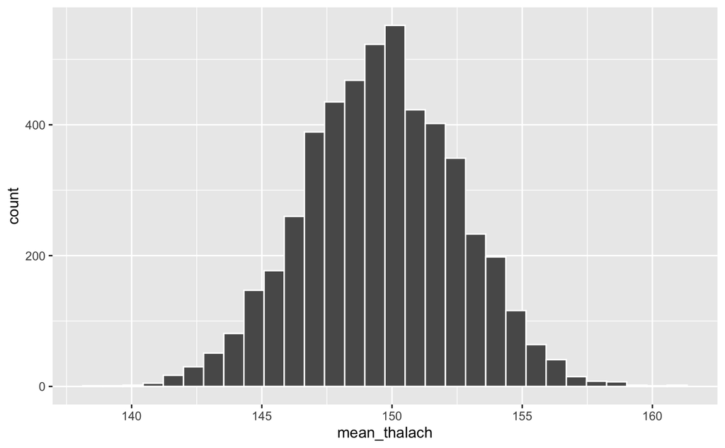

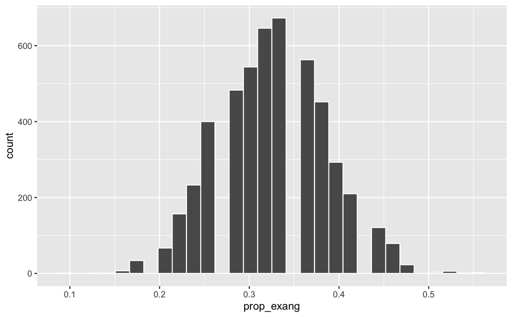

Obtain standard errors of the sampling distribution of mean_thalach and prop_exang directly as the standard deviations of the sampling distributions held in rep_sample_50

```r
std_errs <- sum_rep_sample_50 %>%
  summarise(
    se_mean_thalach = sd(mean_thalach),
    se_prop_exang = sd(prop_exang)
  )
std_errs
```

| se_mean_thalach | se_prop_exang |
| --- | --- |
| 2.960825 | 0.0605268 |

Repeat steps 7. and 9. (omitting step 8.) once more with samples of size 100-patients, and again with samples of size 200-patients. How do the standard errors of mean_thalach and prop_exang change as sample size increases? Does the uncertainty in the calculated statistics increase or decrease as sample size increases? [Hint - it’s OK to copy, paste and alter code to do this!]

```r
rep_sample_100 <- heart %>%
  rep_sample_n(size = 100, reps = 5000) %>%
  summarise(
    mean_thalach = mean(thalach),
    prop_exang = mean(exang)
  )

std_errs_100 <- rep_sample_100 %>%
  summarise(
    se_mean_thalach = sd(mean_thalach),
    se_prop_exang = sd(prop_exang)
  )

rep_sample_200 <- heart %>%
  rep_sample_n(size = 200, reps = 5000) %>%
  summarise(
    mean_thalach = mean(thalach),
    prop_exang = mean(exang)
  )

std_errs_200 <- rep_sample_200 %>%
  summarise(
    se_mean_thalach = sd(mean_thalach),
    se_prop_exang = sd(prop_exang)
  )
std_errs_100
```

| se_mean_thalach | se_prop_exang |
| --- | --- |
| 1.88936 | 0.03866214 |

```r
std_errs_200
```

| se_mean_thalach | se_prop_exang |
| --- | --- |
| 0.9444914 | 0.01921201 |